# How to use this package

Mauricio Vargas

2020-01-12

# Galactic Federation

This example is inspired after the visualizations from Hausmann et al. (2014) but heavily inspired after Rick and Morty to keep it simple and lightweight.

## Package data

I’ll use the Galactic Federation dataset to illustrate the essential usage of the functions within this package.

```r
library(binet)

galactic_federation
```

```
## # A tibble: 108 x 3
##    planet                      product export_value
##    <chr>                       <chr>          <dbl>
##  1 Bepis 9                     alpha              0
##  2 Bird World                  alpha              0
##  3 Crepktct 4                  alpha              0
##  4 Earth C-137                 alpha            345
##  5 Gear World                  alpha              0
##  6 Glaagablaaga                alpha             23
##  7 Gromflom Prime              alpha              0
##  8 Galactic Federation Prison  alpha              0
##  9 Galactic Federation Outpost alpha              0
## 10 Bepis 9                     beta              10
## # … with 98 more rows
```

## Balassa Index

You can obtain Balassa Index with `balassa_index()`.

```r
bi <- balassa_index(
  data = galactic_federation,
  source = "planet",
  target = "product",
  value = "export_value"
)

bi
```

```
## 9 x 12 sparse Matrix of class "dgCMatrix"
##
## Bepis 9                     . . . 1 . . . . . . 1 .
## Bird World                  . . . . . 1 . . . . . .
## Crepktct 4                  . . . . . 1 . 1 1 . . .
## Earth C-137                 1 . 1 1 . . . . 1 1 1 1
## Galactic Federation Outpost . . . 1 . 1 . 1 . . . .
## Galactic Federation Prison  . 1 . . . 1 . . . . . 1
## Gear World                  . . . 1 1 . . . . 1 1 .
## Glaagablaaga                . . . . 1 1 1 1 . 1 . .
## Gromflom Prime              . 1 . . . . . . . . . .
```

Another possibility is to obtain Balassa Index without discretization.

```r
bi_dec <- balassa_index(
  data =galactic_federation,
  source = "planet",
  target = "product",
  value = "export_value",
  discrete = F
)

bi_dec
```

```
## 9 x 12 sparse Matrix of class "dgCMatrix"
##
## Bepis 9                      0.0000000 0.026913032 0.74579894 8.74935328
## Bird World                   0.0000000 0.000000000 0.00000000 0.00000000
## Crepktct 4                   0.0000000 0.000000000 0.00000000 0.00000000
## Earth C-137                 12.0649696 0.284187435 8.37464955 1.98074843
## Galactic Federation Outpost  0.0000000 0.834303980 0.00000000 1.00455538
## Galactic Federation Prison   0.0000000 1.355514376 0.03210535 0.06974898
## Gear World                   0.0000000 0.000000000 0.00000000 2.74578470
## Glaagablaaga                 0.1405337 0.001211063 0.67120584 0.48606562
## Gromflom Prime               0.0000000 6.107206427 0.00000000 0.00000000
##
## Bepis 9                        0.00000 0.6988605 0.00000000 0.0000000 0.000000
## Bird World                     0.00000 1.7765035 0.00000000 0.0000000 0.000000
## Crepktct 4                     0.00000 1.5990130 0.16492994 1.9473219 8.574707
## Earth C-137                    0.00000 0.4199772 0.29704099 0.8670460 6.434650
## Galactic Federation Outpost    0.00000 1.3540423 0.08938398 1.2312457 0.000000
## Galactic Federation Prison     0.00000 1.3538130 0.05585553 0.2931041 0.000000
## Gear World                  1587.75000 0.0000000 0.00000000 0.0000000 0.000000
## Glaagablaaga                   1.12427 1.0482702 2.16247313 1.7021496 0.000000
## Gromflom Prime                 0.00000 0.1903057 0.00000000 0.0000000 0.000000
##
## Bepis 9                      0.9883885  2.75899852  0.0000000
## Bird World                   0.0000000  0.00000000  0.0000000
## Crepktct 4                   0.9422755  0.00000000  0.0000000
## Earth C-137                  3.5355222  9.86909579  7.7215805
## Galactic Federation Outpost  0.0000000  0.00000000  0.0000000
## Galactic Federation Prison   0.8864252  0.39590032 11.2930567
## Gear World                  87.2390110 19.48159509  0.0000000
## Glaagablaaga                 1.2354613  0.06897361  0.0000000
## Gromflom Prime               0.0000000  0.00000000  0.3401714
```

## Complexity Measures

You can compute complexity indexes (e.g. such as the Economic Complexity Index and Product Complexity Index) by using `complexity_measures()`. The calculations methods are *fitness* (default), *reflections*, *eigenvalues*. See (Mariani et al. 2015) for the methodological details.

The eigenvalues also calls the reflections methods in order to correct the index sign in some special cases when the correlation between the output from both methods is negative.

## Complexity-Fitness

```r
com_fit <- complexity_measures(balassa_index = bi)

com_fit$complexity_index_source
```

```
##                     Bepis 9                  Bird World
##                0.0115128434                0.0001097279
##                  Crepktct 4                 Earth C-137
##                0.0212756540                8.3417128754
## Galactic Federation Outpost  Galactic Federation Prison
##                0.0081891360                0.0059094230
##                  Gear World                Glaagablaaga
##                0.1670017470                0.4440184218
##              Gromflom Prime
##                0.0002701715
```

```r
com_fit$complexity_index_target
```

```
##        alpha         beta        delta      epsilon          eta        gamma
## 5.7151134328 0.0003691566 5.7151134328 0.0039046311 0.0935850244 0.0001104686
##         iota        kappa       lambda           mu        theta         zeta
## 0.3405363984 0.0049668423 0.0181804513 0.0920772586 0.0088859916 0.0071569113
```

## Reflections

```r
com_ref <- complexity_measures(
  balassa_index = bi,
  method = "reflections"
)

com_ref$complexity_index_source
```

```
##                     Bepis 9                  Bird World
##                   0.9026556                  -0.1485957
##                  Crepktct 4                 Earth C-137
##                   0.2037342                   0.6038710
## Galactic Federation Outpost  Galactic Federation Prison
##                   0.3261197                  -0.8899340
##                  Gear World                Glaagablaaga
##                   0.8226508                   0.4172960
##              Gromflom Prime
##                  -2.2377975
```

```r
com_ref$complexity_index_target
```

```
##       alpha        beta       delta     epsilon         eta       gamma
##  0.51300951 -2.86348750  0.51300951  0.60639354  0.53809077 -0.45605530
##        iota       kappa      lambda          mu       theta        zeta
##  0.22239761  0.06417622  0.20138018  0.52973035  0.78173132 -0.65037622
```

## Eigenvalues

```r
com_eig <- complexity_measures(
  balassa_index = bi,
  method = "eigenvalues"
)

com_eig$complexity_index_source
```

```
##                     Bepis 9                  Bird World
##                  0.80930502                 -0.05046209
##                  Crepktct 4                 Earth C-137
##                  0.27062552                  0.52370159
## Galactic Federation Outpost  Galactic Federation Prison
##                  0.37269206                 -0.89692342
##                  Gear World                Glaagablaaga
##                  0.77446154                  0.48135621
##              Gromflom Prime
##                 -2.28475643
```

```r
com_eig$complexity_index_target
```

```
##      alpha       beta      delta    epsilon        eta      gamma       iota
##  0.4160916 -2.9019977  0.4160916  0.5672637  0.5796113 -0.3500494  0.3496442
##      kappa     lambda         mu      theta       zeta
##  0.1825819  0.2175311  0.5251047  0.6966412 -0.6985142
```

## Proximity

Proximity matrices are used to create projections e.g. (country-country and product-product networks) for bipartite networks. Using `proximity()` is straightforward.

```r
pro <- proximity(
  balassa_index = bi,
  balassa_sum_source = com_fit$balassa_sum_source,
  balassa_sum_target = com_fit$balassa_sum_target
)

pro$proximity_source
```

```
## 9 x 9 sparse Matrix of class "dsCMatrix"
##                               Bepis 9 Bird World Crepktct 4 Earth C-137
## Bepis 9                     1.0000000  .          .           0.2857143
## Bird World                  .          1.0000000  0.3333333   .
## Crepktct 4                  .          0.3333333  1.0000000   0.1428571
## Earth C-137                 0.2857143  .          0.1428571   1.0000000
## Galactic Federation Outpost 0.3333333  0.3333333  0.6666667   0.1428571
## Galactic Federation Prison  .          0.3333333  0.3333333   0.1428571
## Gear World                  0.5000000  .          .           0.4285714
## Glaagablaaga                .          0.2000000  0.4000000   0.1428571
## Gromflom Prime              .          .          .           .
##                             Galactic Federation Outpost
## Bepis 9                                       0.3333333
## Bird World                                    0.3333333
## Crepktct 4                                    0.6666667
## Earth C-137                                   0.1428571
## Galactic Federation Outpost                   1.0000000
## Galactic Federation Prison                    0.3333333
## Gear World                                    0.2500000
## Glaagablaaga                                  0.4000000
## Gromflom Prime                                .
##                             Galactic Federation Prison Gear World Glaagablaaga
## Bepis 9                                      .          0.5000000    .
## Bird World                                   0.3333333  .            0.2000000
## Crepktct 4                                   0.3333333  .            0.4000000
## Earth C-137                                  0.1428571  0.4285714    0.1428571
## Galactic Federation Outpost                  0.3333333  0.2500000    0.4000000
## Galactic Federation Prison                   1.0000000  .            0.2000000
## Gear World                                   .          1.0000000    0.4000000
## Glaagablaaga                                 0.2000000  0.4000000    1.0000000
## Gromflom Prime                               0.3333333  .            .
##                             Gromflom Prime
## Bepis 9                          .
## Bird World                       .
## Crepktct 4                       .
## Earth C-137                      .
## Galactic Federation Outpost      .
## Galactic Federation Prison       0.3333333
## Gear World                       .
## Glaagablaaga                     .
## Gromflom Prime                   1.0000000
```

```r
pro$proximity_target
```

```
## 12 x 12 sparse Matrix of class "dsCMatrix"
##
## alpha   1.0000000 .   1.0000000 0.25 .         .   .         .
## beta    .         1.0 .         .    .         0.2 .         .
## delta   1.0000000 .   1.0000000 0.25 .         .   .         .
## epsilon 0.2500000 .   0.2500000 1.00 0.2500000 0.2 .         0.2500000
## eta     .         .   .         0.25 1.0000000 0.2 0.5000000 0.3333333
## gamma   .         0.2 .         0.20 0.2000000 1.0 0.2000000 0.6000000
## iota    .         .   .         .    0.5000000 0.2 1.0000000 0.3333333
## kappa   .         .   .         0.25 0.3333333 0.6 0.3333333 1.0000000
## lambda  0.5000000 .   0.5000000 0.25 .         0.2 .         0.3333333
## mu      0.3333333 .   0.3333333 0.50 0.6666667 0.2 0.3333333 0.3333333
## theta   0.3333333 .   0.3333333 0.75 0.3333333 .   .         .
## zeta    0.5000000 0.5 0.5000000 0.25 .         0.2 .         .
##
## alpha   0.5000000 0.3333333 0.3333333 0.5000000
## beta    .         .         .         0.5000000
## delta   0.5000000 0.3333333 0.3333333 0.5000000
## epsilon 0.2500000 0.5000000 0.7500000 0.2500000
## eta     .         0.6666667 0.3333333 .
## gamma   0.2000000 0.2000000 .         0.2000000
## iota    .         0.3333333 .         .
## kappa   0.3333333 0.3333333 .         .
## lambda  1.0000000 0.3333333 0.3333333 0.5000000
## mu      0.3333333 1.0000000 0.6666667 0.3333333
## theta   0.3333333 0.6666667 1.0000000 0.3333333
## zeta    0.5000000 0.3333333 0.3333333 1.0000000
```

## Networks

The `projections()` function is designed to use `igraph` for the internal computations and also to pass proximity-based networks to `igraph`, `ggraph` or export to Cytoscape by saving the output as csv/tsv.

```r
net <- projections(
  proximity_source = pro$proximity_source,
  proximity_target = pro$proximity_target,
  avg_links = 4,
  tolerance = 0.05
)

net$network_source
```

```
## IGRAPH 4d07ccd UNW- 9 17 --
## + attr: name (v/c), weight (e/n)
## + edges from 4d07ccd (vertex names):
##  [1] Bepis 9                    --Gear World
##  [2] Bird World                 --Galactic Federation Outpost
##  [3] Bird World                 --Galactic Federation Prison
##  [4] Crepktct 4                 --Galactic Federation Outpost
##  [5] Earth C-137                --Gear World
##  [6] Galactic Federation Outpost--Glaagablaaga
##  [7] Galactic Federation Prison --Gromflom Prime
##  [8] Gear World                 --Glaagablaaga
## + ... omitted several edges
```

```r
net$network_target
```

```
## IGRAPH 88a4694 UNW- 12 15 --
## + attr: name (v/c), weight (e/n)
## + edges from 88a4694 (vertex names):
##  [1] alpha  --delta  beta   --zeta   delta  --zeta   epsilon--theta
##  [5] eta    --iota   eta    --mu     gamma  --kappa  kappa  --mu
##  [9] lambda --theta  lambda --zeta   mu     --theta  alpha  --zeta
## [13] alpha  --lambda delta  --lambda epsilon--mu
```

Just two basic examples with `ggraph`.

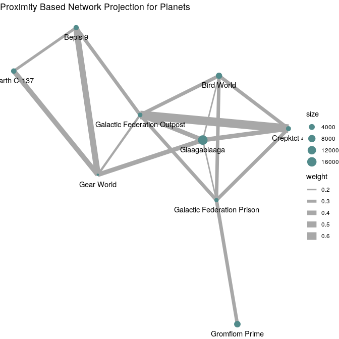

```r
set.seed(200100)
library(igraph)
library(ggraph)

aggregated_planets <- aggregate(galactic_federation$export_value, by = list(planet = galactic_federation$planet), FUN = sum)
aggregated_planets_2 <- aggregated_planets$x
names(aggregated_planets_2) <- aggregated_planets$planet
V(net$network_source)$size <- aggregated_planets_2[match(V(net$network_source)$name, names(aggregated_planets_2))]

net$network_source %>%
  ggraph(layout = "kk") +
  geom_edge_link(aes(edge_width = weight), edge_colour = "#a8a8a8") +
  geom_node_point(aes(size = size), color = "darkslategray4") +
  geom_node_text(aes(label = name), vjust = 2.2) +
  ggtitle("Proximity Based Network Projection for Planets") +
  theme_void()
```

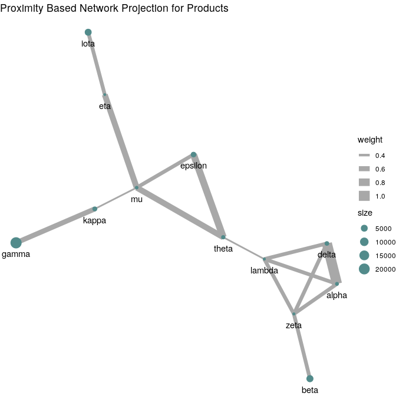

```r
set.seed(200100)

aggregated_products <- aggregate(galactic_federation$export_value, by = list(product = galactic_federation$product), FUN = sum)
aggregated_products_2 <- aggregated_products$x
names(aggregated_products_2) <- aggregated_products$product
V(net$network_target)$size <- aggregated_products_2[match(V(net$network_target)$name, names(aggregated_products_2))]

net$network_target %>%
  ggraph(layout = "kk") +
  geom_edge_link(aes(edge_width = weight), edge_colour = "#a8a8a8") +
  geom_node_point(aes(size = size), color = "darkslategray4") +
  geom_node_text(aes(label = name), vjust = 2.2) +
  ggtitle("Proximity Based Network Projection for Products") +
  theme_void()
```

# References

Hausmann, Ricardo, César Hidalgo, Sebastián Bustos, Michele Coscia, Alexander Simoes, and Muhammed Yildirim. 2014. *The Atlas of Economic Complexity: Mapping Paths to Prosperity*. MIT Press. https://doi.org/10.7551/mitpress/9647.001.0001.

Mariani, Manuel, Alexandre Vidmer, Matsúš Medo, and Yi-Cheng Zhang. 2015. “Measuring Economic Complexity of Countries and Products: Which Metric to Use?” *The European Physical Journal B* 88 (11). Springer: 293. https://doi.org/10.1140/epjb/e2015-60298-7.